# NSHQ14 well logs from 2018

Source file: 200814_Oman_well_logs_14C_carbonate.Rmd

Daniel Nothaft

28 Jul 2024

# 1 Setup

## 1.1 Load code libraries

```r
# load libraries
library(tidyverse) # dplyr, tidyr, ggplot
library(readxl) # reading excel files
library(knitr) # generating reports
library(ggpmisc) # add equations of best fit to ggplot
library(scales) # making log scales with exponents
library(lemon) # repeat axis lines for paneled figures in ggplot

# global knitting options for automatic saving of all plots as .png and .pdf
knitr::opts_chunk$set(
  dev = c("png", "pdf"), fig.keep = "all",
  dev.args = list(pdf = list(encoding = "WinAnsi", useDingbats = FALSE)),
  fig.path = file.path("fig_output/", paste0(gsub("\\.[Rr]md", "/", knitr::current_input()))),
  cache.path = file.path("cache/", paste0(gsub("\\.[Rr]md", "/", knitr::current_input())))
)
```

```r
# source all relevant scripting files
source(file.path("scripts", "plotting_functions.R"))
```

## 1.2 Load data

```r
# read NSHQ14 borehole log from March 17th, 2018
NSHQ14_profile_raw <- read_xlsx("data_raw/Summary_metadata/NSHQ14_QL40IDRO_20180317_down_5cm.xlsx", na = c("-99999.00", "-99999"))

# read BA3A borehole log from March 18th, 2018
BA3A_profile_raw <- read_xlsx("data_raw/Summary_metadata/BA3A_QL40IDRO_20180318_down_5cm.xlsx", na = c("-99999.00", "-99999"))

# Read in conversion from Ag/AgCl electrode to SHE as function of T
Ag_AgCl_E_T <- read_xlsx("data_raw/Summary_metadata/Ag_AgCl_E_T.xlsx", na = "NA")

# Load carbonate mineral isotope data from wells
data_carb <- read_xlsx("data_raw/Summary_metadata/Carbonate_isotopes_BA3A_NSHQ14.xlsx", na = "NA")

# Load carbonate mineral isotope data from wells
BA3A_vein_types <- read_xlsx("data_raw/Summary_metadata/BA3A_vein_types_counts.xlsx", na = "NA")
```

# 2 Vein types

Descriptions of carbonate-bearing vein types from Proc. Oman Drilling Project, Init. Rpts. Phase 2, Hole BA3A. Veins

*Ca veins* Ca veins are layered composite veins composed of green to black serpentine and carbonate minerals. They are pervasive in the uppermost cores. The Ca veins are subdivided into three subgroups in their appearance: Ca1 veins have dark colored serpentine cores with carbonate rims; Ca2 veins have carbonate cores with serpentine rims (this vein type was not observed in Hole BA3A). A few Ca3 veins include waxy green serpentine and carbonate minerals. For the most part, in describing the core from Hole BA3A, we did not record subtypes based on whether the cores or the rims were calcite-bearing, unlike in the description of the upper 200 meters of the core from Hole BA1B.

Show first few lines of vein data:

```r
head(BA3A_vein_types)
```

| depth_sampled_mbgl | vein_type |
| --- | --- |
| 1.16 | Cb |
| 2.78 | Ca |
| 2.89 | Cb |
| 3.20 | Ca |
| 3.30 | Cb |
| 3.58 | Ca |

Focus on carbonate vein data

```r
BA3A_vein_types_carb <- BA3A_vein_types %>%
  # make column with value 1 if vein type is a carbonate (Ca or Cb per Oman DP descriptions above), and 0 if any other type of vein
  mutate(vein_type_carbonate = if_else((vein_type == "Ca" | vein_type == "Ca1" | vein_type == "Ca2" | vein_type == "Ca3" | vein_type == "Cb"), 1, 0)) %>%
  # filter for only carbonate veins
  filter(vein_type_carbonate == 1) %>%
  # select only columns for depth and whether vein is carbonate
  select(depth_sampled_mbgl, vein_type_carbonate) %>%
  # add a column identifying sample site as BA3A
  mutate(sampling_site = "BA3A")
```

Plot histogram of carbonate veins in BA3A

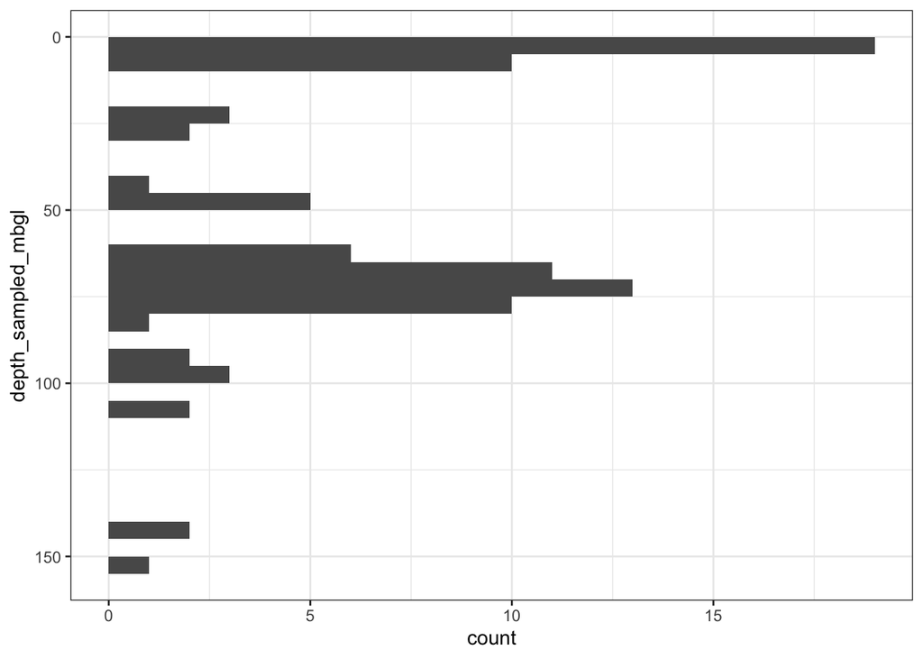

```r
BA3A_vein_types_carb %>% ggplot(
  aes(y = depth_sampled_mbgl)
) +
geom_histogram(binwidth = 5, boundary = 0) +
  scale_y_reverse() +
  theme_bw()
```

# 3 NSHQ14 well log

## 3.1 clean up data

```r
# select relevant columns and rename them
NSHQ14_profile <- NSHQ14_profile_raw %>% select(depth_sampled_mbgl = `DEPT[M]`, P_dbar = PRESSURE, T_C = TEMPERATURE, pH = PH, ORP_mV_Ag_AgCl = REDOX, cond_uS_per_cm = `COND(FW)`)

# Filter out nonsense values (i.e. when probe is above water table)
NSHQ14_profile <- NSHQ14_profile %>% filter(!is.na(ORP_mV_Ag_AgCl))

# print some summary statistics
NSHQ14_profile %>% summary()
```

```
##  depth_sampled_mbgl     P_dbar             T_C              pH
##  Min.   : 11.21     Min.   :  4.967   Min.   :35.13   Min.   :10.36
##  1st Qu.: 81.70     1st Qu.: 74.997   1st Qu.:35.98   1st Qu.:11.05
##  Median :152.19     Median :144.314   Median :37.62   Median :11.12
##  Mean   :152.19     Mean   :143.740   Mean   :37.75   Mean   :11.10
##  3rd Qu.:222.69     3rd Qu.:212.746   3rd Qu.:39.39   3rd Qu.:11.19
##  Max.   :293.18     Max.   :280.155   Max.   :41.17   Max.   :11.26
##  ORP_mV_Ag_AgCl    cond_uS_per_cm
##  Min.   :-902.85   Min.   :1595
##  1st Qu.:-899.70   1st Qu.:3638
##  Median :-889.79   Median :3733
##  Mean   :-850.94   Mean   :4116
##  3rd Qu.:-870.75   3rd Qu.:4905
##  Max.   : -44.29   Max.   :5027
```

```r
# subset the data for readability and print
NSHQ14_profile %>% slice(seq(from = 1, to = 30000, by = 1000)) %>% kable(digits=1)
```

| depth_sampled_mbgl | P_dbar | T_C | pH | ORP_mV_Ag_AgCl | cond_uS_per_cm |
| --- | --- | --- | --- | --- | --- |
| 11.2 | 5.1 | 35.2 | 10.4 | -44.3 | 1594.8 |
| 21.2 | 15.0 | 35.1 | 10.9 | -604.0 | 2541.9 |
| 31.2 | 25.0 | 35.2 | 11.2 | -768.4 | 3518.2 |
| 41.2 | 34.8 | 35.3 | 11.2 | -786.0 | 3598.0 |
| 51.2 | 44.8 | 35.4 | 11.2 | -827.5 | 3620.0 |
| 61.2 | 54.8 | 35.6 | 11.2 | -847.5 | 3633.2 |
| 71.2 | 64.6 | 35.8 | 11.2 | -857.4 | 3640.1 |
| 81.2 | 74.5 | 36.0 | 11.2 | -870.3 | 3634.2 |
| 91.2 | 84.3 | 36.2 | 11.2 | -876.2 | 3639.8 |
| 101.2 | 94.3 | 36.4 | 11.2 | -881.6 | 3648.9 |
| 111.2 | 104.1 | 36.6 | 11.2 | -883.0 | 3640.8 |
| 121.2 | 114.0 | 36.9 | 11.2 | -884.6 | 3643.2 |
| 131.2 | 123.7 | 37.1 | 11.2 | -886.3 | 3667.8 |
| 141.2 | 133.5 | 37.3 | 11.1 | -888.2 | 3701.7 |
| 151.2 | 143.4 | 37.6 | 11.2 | -890.4 | 3724.2 |
| 161.2 | 153.1 | 37.8 | 11.1 | -890.6 | 3785.9 |
| 171.2 | 162.8 | 38.1 | 11.1 | -892.7 | 3961.8 |
| 181.2 | 172.6 | 38.3 | 11.1 | -898.3 | 4782.5 |
| 191.2 | 182.4 | 38.6 | 11.1 | -900.2 | 4839.6 |
| 201.2 | 191.8 | 38.8 | 11.1 | -900.0 | 4866.1 |
| 211.2 | 201.7 | 39.1 | 11.1 | -900.2 | 4882.6 |
| 221.2 | 211.4 | 39.3 | 11.1 | -900.7 | 4901.8 |
| 231.2 | 220.9 | 39.6 | 11.1 | -900.0 | 4921.4 |
| 241.2 | 230.6 | 39.9 | 11.0 | -899.9 | 4943.5 |
| 251.2 | 240.2 | 40.1 | 11.0 | -899.9 | 4956.6 |
| 261.2 | 249.7 | 40.4 | 11.0 | -899.4 | 4969.3 |
| 271.2 | 259.3 | 40.6 | 11.0 | -899.1 | 4985.4 |
| 281.2 | 268.8 | 40.9 | 11.0 | -898.8 | 5003.5 |
| 291.2 | 278.1 | 41.1 | 11.0 | -898.5 | 5024.1 |

## 3.2 Convert to ORP to SHE

Plot conversion between Ag/AgCl electrode and SHE as function of temperature

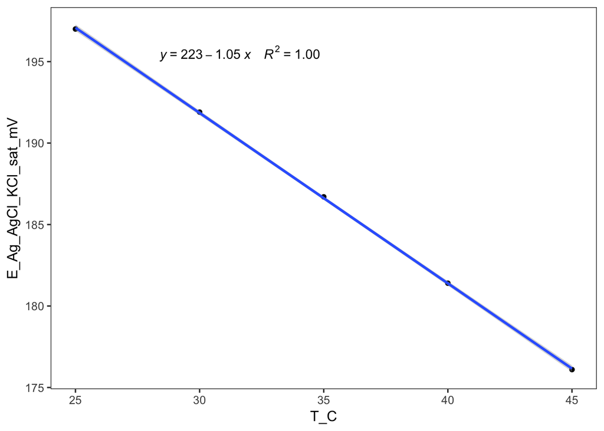

```r
formula <- Ag_AgCl_E_T$E_Ag_AgCl_KCl_sat_mV ~ Ag_AgCl_E_T$T_C

plot_redox_offset_T <- Ag_AgCl_E_T %>% ggplot(aes(x = T_C, y = E_Ag_AgCl_KCl_sat_mV))+
  geom_point()+
  geom_smooth(method="lm")+
    stat_poly_eq(aes(label =  paste(stat(eq.label), stat(rr.label), sep = "~~~~")), formula = y ~ x, parse = TRUE, rr.digits = 2, label.x = .2, label.y = .9)+
  theme_bw(base_size = 12)+
  theme(
    panel.grid = element_blank())

plot_redox_offset_T
```

Save a linear model of the relationship between Ag/AgCl electrode and SHE as function of temperature

```r
Ag_AgCl_E_T_lm <- lm(formula)

Ag_AgCl_E_T_lm_summ <- Ag_AgCl_E_T_lm %>% summary()

Ag_AgCl_E_T_lm_summ
```

```
##
## Call:
## lm(formula = formula)
##
## Residuals:
##     1     2     3     4     5
## -0.08  0.05  0.08  0.01 -0.06
##
## Coefficients:
##                   Estimate Std. Error t value Pr(>|t|)
## (Intercept)     223.230000   0.179722  1242.1 1.15e-09 ***
## Ag_AgCl_E_T$T_C  -1.046000   0.005033  -207.8 2.46e-07 ***
## ---
## Signif. codes:  0 '***' 0.001 '**' 0.01 '*' 0.05 '.' 0.1 ' ' 1
##
## Residual standard error: 0.07958 on 3 degrees of freedom
## Multiple R-squared:  0.9999, Adjusted R-squared:  0.9999
## F-statistic: 4.319e+04 on 1 and 3 DF,  p-value: 2.457e-07
```

Save slope

```r
Ag_AgCl_E_T_lm_slope <- coef(Ag_AgCl_E_T_lm_summ)["Ag_AgCl_E_T$T_C",  "Estimate"]

Ag_AgCl_E_T_lm_slope
```

```
## [1] -1.046
```

Save intercept

```r
Ag_AgCl_E_T_lm_int <- coef(Ag_AgCl_E_T_lm_summ)["(Intercept)",  "Estimate"]

Ag_AgCl_E_T_lm_int
```

```
## [1] 223.23
```

Apply conversion

```r
NSHQ14_profile <- NSHQ14_profile %>% mutate(Eh_mV = ORP_mV_Ag_AgCl + Ag_AgCl_E_T_lm_int + Ag_AgCl_E_T_lm_slope * T_C) # convert probe ORP_mV_Ag_AgCl reading from Ag/AgCl to SHE

# print some summary statistics
NSHQ14_profile %>% select(Eh_mV) %>% summary()
```

```
##      Eh_mV
##  Min.   :-721.6
##  1st Qu.:-718.2
##  Median :-705.9
##  Mean   :-667.2
##  3rd Qu.:-685.2
##  Max.   : 142.1
```

Checking values around 20 m and 25 m

```r
NSHQ14_profile %>% filter(depth_sampled_mbgl > 19.99 & depth_sampled_mbgl < 20.01) %>% select(depth_sampled_mbgl, pH, Eh_mV, cond_uS_per_cm)
```

| depth_sampled_mbgl | pH | Eh_mV | cond_uS_per_cm |
| --- | --- | --- | --- |
| 19.9992 | 10.81921 | -278.0328 | 2409.420 |
| 20.0092 | 10.81963 | -279.7569 | 2410.958 |

```r
NSHQ14_profile %>% filter(depth_sampled_mbgl > 24.99 & depth_sampled_mbgl < 25.01) %>% select(depth_sampled_mbgl, pH, Eh_mV, cond_uS_per_cm)
```

| depth_sampled_mbgl | pH | Eh_mV | cond_uS_per_cm |
| --- | --- | --- | --- |
| 24.9992 | 11.04719 | -536.3237 | 3023.646 |
| 25.0092 | 11.04703 | -536.5785 | 3025.682 |

## 3.3 Hydrostatic pressure

Pressure will be used to assess calculated stability limit of water with respect to molecular hydrogen.

Calculate from theory

```r
P_NSHQ14_atmospheric_Pa <- 95490 # measured ambient pressure with Garmin GPSMAP 64S by DBN in 2019
P_NSHQ14_atmospheric_bar <-  P_NSHQ14_atmospheric_Pa * 1e-5

water_level_NSHQ14_m <- as.numeric(NSHQ14_profile %>% select(depth_sampled_mbgl) %>% min())

NSHQ14_profile <- NSHQ14_profile %>% mutate(water_column_above_m = depth_sampled_mbgl - water_level_NSHQ14_m)


# Hydrostatic pressure in a liquid can be calculated as
#
# p = ρ g h                         (1)
#
# where
#
# p = pressure in liquid (N/m2, Pa, lbf/ft2, psf)
#
# ρ = density of liquid (kg/m3, slugs/ft3)
#
# g = acceleration of gravity (9.81 m/s2, 32.17405 ft/s2)
#
# h = height of fluid column - or depth in the fluid where pressure is measured (m, ft)

# https://www.engineeringtoolbox.com/hydrostatic-pressure-water-d_1632.html

density_water <- 1000 # kg/m3
g = 9.81 # acceleration of gravity, m/s2


NSHQ14_profile <- NSHQ14_profile %>% mutate(P_hydrostatic_calc_Pa = P_NSHQ14_atmospheric_Pa + density_water * g * water_column_above_m)

NSHQ14_profile <- NSHQ14_profile %>% mutate(P_hydrostatic_calc_bar = P_hydrostatic_calc_Pa * 1e-5)

# print some summary statistics
NSHQ14_profile %>% select(P_hydrostatic_calc_bar) %>% summary()
```

```
##  P_hydrostatic_calc_bar
##  Min.   : 0.9549
##  1st Qu.: 7.8702
##  Median :14.7855
##  Mean   :14.7855
##  3rd Qu.:21.7008
##  Max.   :28.6162
```

```r
# convert measured pressure to bar
NSHQ14_profile <- NSHQ14_profile %>% mutate(P_bar = P_dbar / 10)
```

```r
# prepare for plotting
NSHQ14_profile_longer_P <- NSHQ14_profile %>% select(depth_sampled_mbgl, P_hydrostatic_calc_bar, P_bar) %>% gather(-depth_sampled_mbgl, key = parameter, value = P_bar) %>% mutate(type = if_else(parameter == "P_hydrostatic_calc_bar", "calculated", "measured"))
```

Compare theoretical hydrostatic pressure versus measured pressure

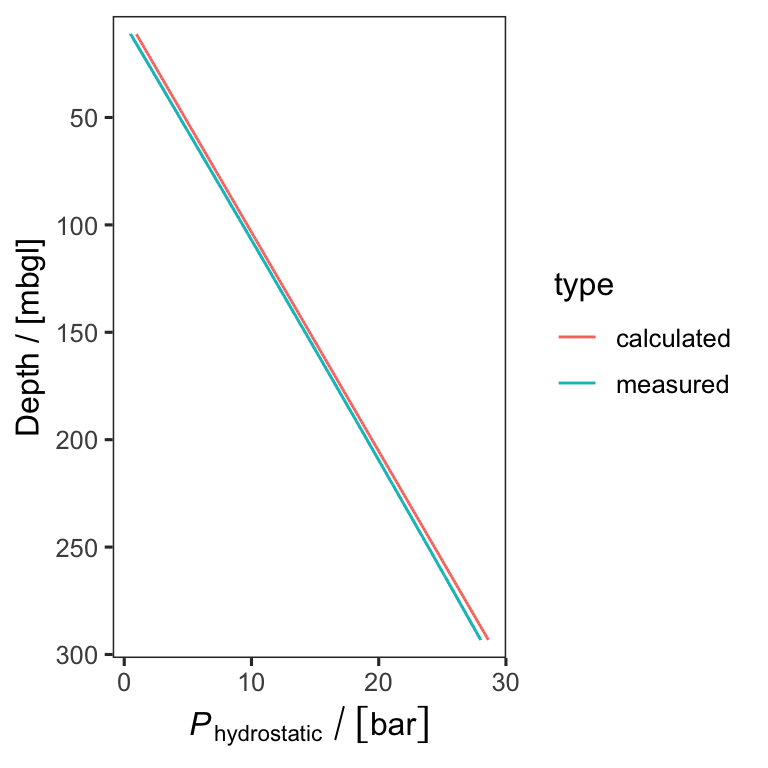

```r
plot_NSHQ14_P <- NSHQ14_profile_longer_P %>% ggplot(aes(x = depth_sampled_mbgl))+
  geom_line(aes(y = P_bar, color = type))+
  scale_x_reverse(name = "Depth / [mbgl]", expand = c(0.03,0.02), breaks = c(0, 50, 100, 150, 200, 250, 300))+
    scale_y_continuous(name = latex2exp::TeX("$\\textit{P}_{hydrostatic}\\,/\\,\\lbrack bar \\rbrack$"))+
  coord_flip()+
  theme_bw(base_size = 12)+
  theme(
    panel.grid = element_blank())

plot_NSHQ14_P
```

They are similar.

## 3.4 Stability limits of water

Eh, f(T,P)

```r
Faraday <- 96485.33212331 # C/mol
R <- 8.31446261815324 # J/(mol⋅K) gas constant

NSHQ14_profile <- NSHQ14_profile %>% mutate(T_K= T_C + 273.15) # convert T to Kelvins

# calculate H20-H2 stability limit
NSHQ14_profile <- NSHQ14_profile %>% mutate(H2O_H2_limit_Eh_f_T_P_mV = (-R*T_K/2/Faraday * log(((10^-pH)^-2)*P_bar))*1000)

NSHQ14_profile %>% select(H2O_H2_limit_Eh_f_T_P_mV) %>% summary()
```

```
##  H2O_H2_limit_Eh_f_T_P_mV
##  Min.   :-733.3
##  1st Qu.:-727.4
##  Median :-722.9
##  Mean   :-717.2
##  3rd Qu.:-714.1
##  Max.   :-625.0
```

```r
# prepare for plotting
NSHQ14_profile_longer_Eh_T_P <- NSHQ14_profile %>% select(depth_sampled_mbgl, Eh_mV, H2O_H2_limit_Eh_f_T_P_mV) %>% gather(-depth_sampled_mbgl, key = parameter, value = Eh_mV)
```

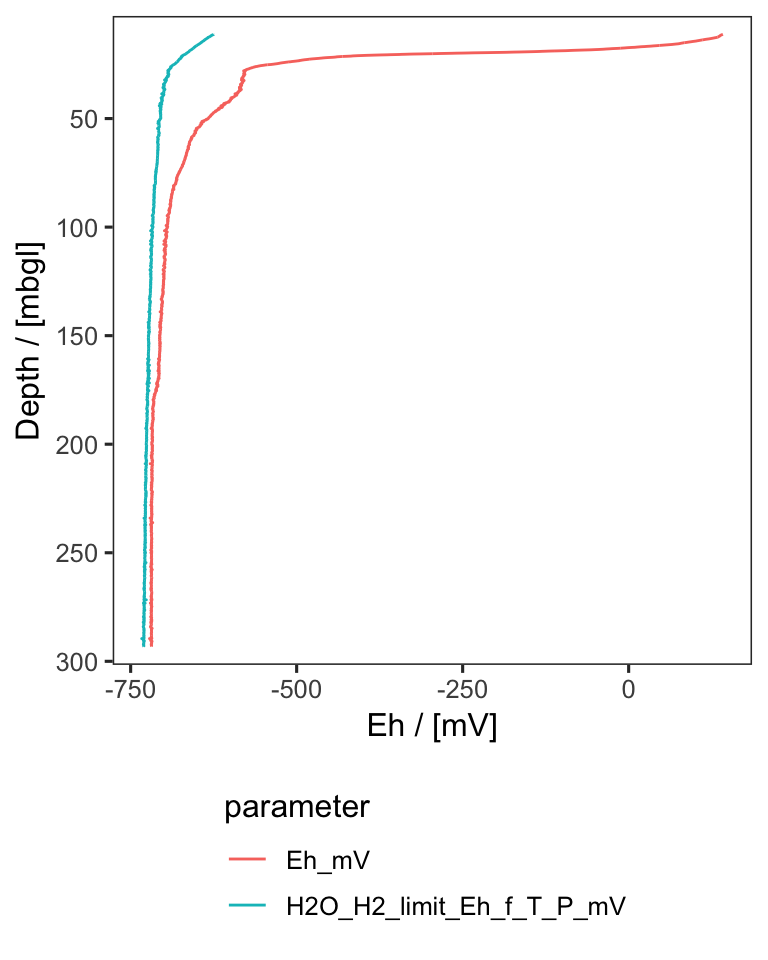

```r
plot_NSHQ14_Eh <- NSHQ14_profile_longer_Eh_T_P %>% ggplot(aes(x = depth_sampled_mbgl))+
  geom_line(aes(y = Eh_mV, color = parameter))+
  scale_x_reverse(name = "Depth / [mbgl]", expand = c(0.03,0.02), breaks = c(0, 50, 100, 150, 200, 250, 300))+
  scale_y_continuous(name = "Eh / [mV]")+
  coord_flip()+
  theme_bw(base_size = 12)+
  theme(
    panel.grid = element_blank(),
    legend.position = "bottom",
    legend.direction = "vertical")

plot_NSHQ14_Eh
```

# 4 BA3A well log

## 4.1 clean up data

```r
# select relevant columns and rename them
BA3A_profile <- BA3A_profile_raw %>% select(depth_sampled_mbgl = `DEPT[M]`, P_dbar = PRESSURE, T_C = TEMPERATURE, pH = PH, ORP_mV_Ag_AgCl = REDOX, cond_uS_per_cm = `COND(FW)`)

# Filter out nonsense values (i.e. when probe is above water table)
BA3A_profile <- BA3A_profile %>% filter(!is.na(ORP_mV_Ag_AgCl))

# print some summary statistics
BA3A_profile %>% summary()
```

```
##  depth_sampled_mbgl     P_dbar            T_C              pH
##  Min.   :  8.293    Min.   :  4.38   Min.   :35.00   Min.   : 9.37
##  1st Qu.: 79.243    1st Qu.: 75.20   1st Qu.:35.96   1st Qu.:10.62
##  Median :150.193    Median :145.13   Median :37.65   Median :10.74
##  Mean   :150.193    Mean   :144.62   Mean   :37.75   Mean   :10.67
##  3rd Qu.:221.143    3rd Qu.:214.26   3rd Qu.:39.43   3rd Qu.:10.81
##  Max.   :292.093    Max.   :282.88   Max.   :41.23   Max.   :10.93
##  ORP_mV_Ag_AgCl   cond_uS_per_cm
##  Min.   :-894.7   Min.   : 985.9
##  1st Qu.:-870.5   1st Qu.:1573.4
##  Median :-857.2   Median :1622.2
##  Mean   :-855.3   Mean   :1998.7
##  3rd Qu.:-850.4   3rd Qu.:2382.0
##  Max.   :-728.3   Max.   :3563.7
```

```r
# subset the data for readability and print
BA3A_profile %>% slice(seq(from = 1, to = 30000, by = 1000)) %>% kable(digits=1)
```

| depth_sampled_mbgl | P_dbar | T_C | pH | ORP_mV_Ag_AgCl | cond_uS_per_cm |
| --- | --- | --- | --- | --- | --- |
| 8.3 | 4.4 | 35.0 | 9.5 | -729.5 | 987.2 |
| 18.3 | 14.6 | 35.1 | 9.9 | -777.0 | 1012.9 |
| 28.3 | 24.5 | 35.1 | 10.6 | -814.0 | 1237.3 |
| 38.3 | 34.5 | 35.2 | 10.8 | -833.8 | 1425.8 |
| 48.3 | 44.4 | 35.4 | 10.9 | -840.9 | 1483.1 |
| 58.3 | 54.4 | 35.5 | 10.9 | -844.1 | 1538.0 |
| 68.3 | 64.3 | 35.7 | 10.9 | -848.1 | 1580.5 |
| 78.3 | 74.2 | 35.9 | 10.9 | -850.0 | 1612.0 |
| 88.3 | 84.1 | 36.2 | 10.9 | -853.7 | 1592.4 |
| 98.3 | 94.0 | 36.4 | 10.8 | -852.3 | 1575.5 |
| 108.3 | 103.9 | 36.6 | 10.8 | -851.9 | 1571.2 |
| 118.3 | 113.8 | 36.9 | 10.8 | -852.7 | 1579.2 |
| 128.3 | 123.6 | 37.1 | 10.8 | -854.8 | 1600.9 |
| 138.3 | 133.5 | 37.4 | 10.8 | -856.4 | 1634.5 |
| 148.3 | 143.2 | 37.6 | 10.8 | -857.1 | 1616.6 |
| 158.3 | 153.1 | 37.8 | 10.7 | -856.0 | 1620.6 |
| 168.3 | 162.8 | 38.1 | 10.7 | -858.7 | 1656.1 |
| 178.3 | 172.6 | 38.4 | 10.6 | -862.9 | 1815.3 |
| 188.3 | 182.4 | 38.6 | 10.6 | -863.4 | 2022.8 |
| 198.3 | 192.1 | 38.8 | 10.6 | -868.9 | 2382.3 |
| 208.3 | 201.8 | 39.1 | 10.7 | -884.4 | 3205.1 |
| 218.3 | 211.7 | 39.4 | 10.7 | -886.9 | 3321.6 |
| 228.3 | 221.3 | 39.6 | 10.7 | -889.1 | 3446.7 |
| 238.3 | 231.0 | 39.9 | 10.8 | -890.8 | 3496.6 |
| 248.3 | 240.6 | 40.1 | 10.7 | -883.9 | 3055.5 |
| 258.3 | 250.4 | 40.4 | 10.6 | -876.7 | 2705.6 |
| 268.3 | 259.9 | 40.6 | 10.6 | -872.1 | 2402.5 |
| 278.3 | 269.5 | 40.9 | 10.5 | -866.8 | 2193.3 |
| 288.3 | 279.2 | 41.1 | 10.5 | -863.7 | 2078.1 |

## 4.2 Convert to ORP to SHE

Apply conversion

```r
BA3A_profile <- BA3A_profile %>% mutate(Eh_mV = ORP_mV_Ag_AgCl + Ag_AgCl_E_T_lm_int + Ag_AgCl_E_T_lm_slope * T_C) # convert probe ORP_mV_Ag_AgCl reading from Ag/AgCl to SHE

# print some summary statistics
BA3A_profile %>% select(Eh_mV) %>% summary()
```

```
##      Eh_mV
##  Min.   :-713.3
##  1st Qu.:-689.7
##  Median :-673.3
##  Mean   :-671.6
##  3rd Qu.:-664.8
##  Max.   :-541.7
```

## 4.3 Hydrostatic pressure

Pressure will be used to assess calculated stability limit of water with respect to molecular hydrogen.

Calculate from theory

```r
P_BA3A_atmospheric_Pa <- 95490 # measured ambient pressure with Garmin GPSMAP 64S by DBN in 2019
P_BA3A_atmospheric_bar <-  P_BA3A_atmospheric_Pa * 1e-5

water_level_BA3A_m <- as.numeric(BA3A_profile %>% select(depth_sampled_mbgl) %>% min())

BA3A_profile <- BA3A_profile %>% mutate(water_column_above_m = depth_sampled_mbgl - water_level_BA3A_m)


# Hydrostatic pressure in a liquid can be calculated as
#
# p = ρ g h                         (1)
#
# where
#
# p = pressure in liquid (N/m2, Pa, lbf/ft2, psf)
#
# ρ = density of liquid (kg/m3, slugs/ft3)
#
# g = acceleration of gravity (9.81 m/s2, 32.17405 ft/s2)
#
# h = height of fluid column - or depth in the fluid where pressure is measured (m, ft)

# https://www.engineeringtoolbox.com/hydrostatic-pressure-water-d_1632.html

density_water <- 1000 # kg/m3
g = 9.81 # acceleration of gravity, m/s2


BA3A_profile <- BA3A_profile %>% mutate(P_hydrostatic_calc_Pa = P_BA3A_atmospheric_Pa + density_water * g * water_column_above_m)

BA3A_profile <- BA3A_profile %>% mutate(P_hydrostatic_calc_bar = P_hydrostatic_calc_Pa * 1e-5)

# print some summary statistics
BA3A_profile %>% select(P_hydrostatic_calc_bar) %>% summary()
```

```
##  P_hydrostatic_calc_bar
##  Min.   : 0.9549
##  1st Qu.: 7.9151
##  Median :14.8753
##  Mean   :14.8753
##  3rd Qu.:21.8355
##  Max.   :28.7957
```

```r
# convert measured pressure to bar
BA3A_profile <- BA3A_profile %>% mutate(P_bar = P_dbar / 10)
```

```r
# prepare for plotting
BA3A_profile_longer_P <- BA3A_profile %>% select(depth_sampled_mbgl, P_hydrostatic_calc_bar, P_bar) %>% gather(-depth_sampled_mbgl, key = parameter, value = P_bar) %>% mutate(type = if_else(parameter == "P_hydrostatic_calc_bar", "calculated", "measured"))
```

Compare theoretical hydrostatic pressure versus measured pressure

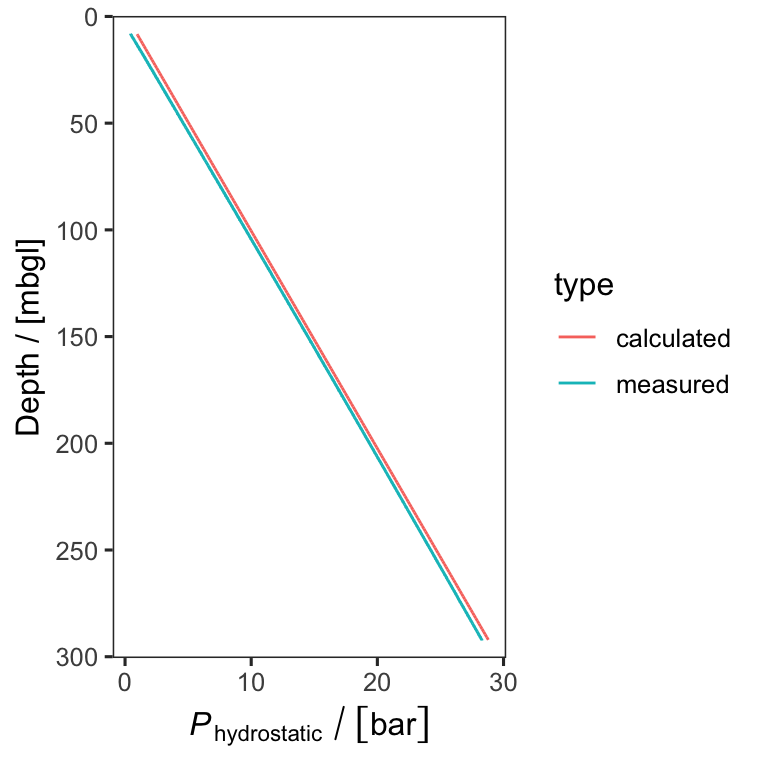

```r
plot_BA3A_P <- BA3A_profile_longer_P %>% ggplot(aes(x = depth_sampled_mbgl))+
  geom_line(aes(y = P_bar, color = type))+
  scale_x_reverse(name = "Depth / [mbgl]", expand = c(0.03,0.02), breaks = c(0, 50, 100, 150, 200, 250, 300))+
    scale_y_continuous(name = latex2exp::TeX("$\\textit{P}_{hydrostatic}\\,/\\,\\lbrack bar \\rbrack$"))+
  coord_flip()+
  theme_bw(base_size = 12)+
  theme(
    panel.grid = element_blank())

plot_BA3A_P
```

They are similar.

## 4.4 Stability limits of water

Eh, f(T,P)

```r
Faraday <- 96485.33212331 # C/mol
R <- 8.31446261815324 # J/(mol⋅K) gas constant

BA3A_profile <- BA3A_profile %>% mutate(T_K= T_C + 273.15) # convert T to Kelvins

# calculate H20-H2 stability limit
BA3A_profile <- BA3A_profile %>% mutate(H2O_H2_limit_Eh_f_T_P_mV = (-R*T_K/2/Faraday * log(((10^-pH)^-2)*P_bar))*1000)

BA3A_profile %>% select(H2O_H2_limit_Eh_f_T_P_mV) %>% summary()
```

```
##  H2O_H2_limit_Eh_f_T_P_mV
##  Min.   :-714.7
##  1st Qu.:-702.1
##  Median :-696.9
##  Mean   :-691.0
##  3rd Qu.:-692.8
##  Max.   :-563.9
```

```r
# prepare for plotting
BA3A_profile_longer_Eh_T_P <- BA3A_profile %>% select(depth_sampled_mbgl, Eh_mV, H2O_H2_limit_Eh_f_T_P_mV) %>% gather(-depth_sampled_mbgl, key = parameter, value = Eh_mV)
```

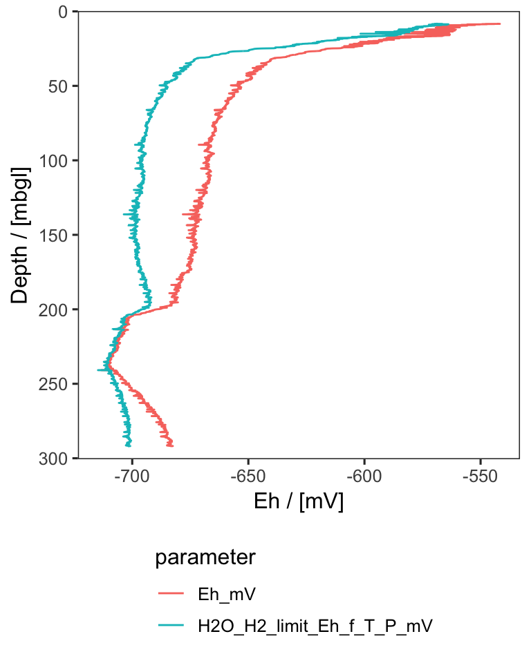

```r
plot_BA3A_Eh <- BA3A_profile_longer_Eh_T_P %>% ggplot(aes(x = depth_sampled_mbgl))+
  geom_line(aes(y = Eh_mV, color = parameter))+
  scale_x_reverse(name = "Depth / [mbgl]", expand = c(0.03,0.02), breaks = c(0, 50, 100, 150, 200, 250, 300))+
  scale_y_continuous(name = "Eh / [mV]")+
  coord_flip()+
  theme_bw(base_size = 12)+
  theme(
    panel.grid = element_blank(),
    legend.position = "bottom",
    legend.direction = "vertical")

plot_BA3A_Eh
```

# 5 NSHQ14 BA3A H$_2$O-H$_2$ stability limit plot

Join NSHQ14 and BA3A Eh data sets

```r
BA3A_NSHQ14_profile_longer_Eh_T_P <- full_join(BA3A_profile_longer_Eh_T_P %>% mutate(sampling_site = "BA3A"), NSHQ14_profile_longer_Eh_T_P %>% mutate(sampling_site = "NSHQ14"))
```

[output not shown]

```r
BA3A_NSHQ14_profile_longer_Eh_T_P <- BA3A_NSHQ14_profile_longer_Eh_T_P %>%
  mutate(
    parameter = case_when(
        parameter == "Eh_mV" ~ "Measured",
        parameter == "H2O_H2_limit_Eh_f_T_P_mV" ~ "Stability limit of water with respect to molecular hydrogen\nas a function of measured temperature, pressure, and pH"
    )
  )
```

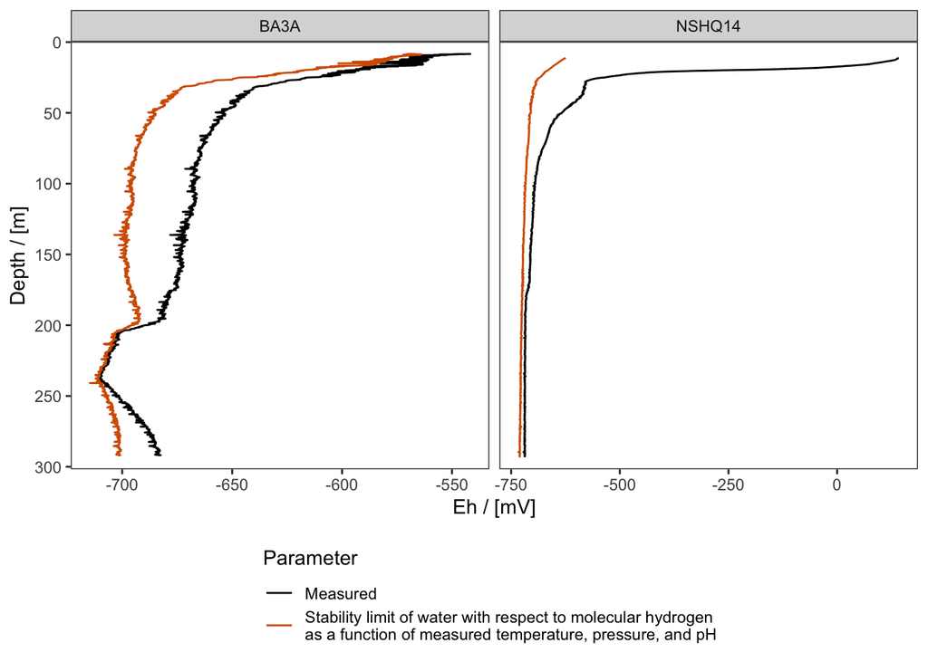

```r
plot_BA3A_NSHQ14_Eh <- BA3A_NSHQ14_profile_longer_Eh_T_P  %>% ggplot(aes(x = depth_sampled_mbgl))+
  geom_line(aes(y = Eh_mV, color = parameter))+
  scale_x_reverse(name = "Depth / [m]", expand = c(0.03,0.02), breaks = c(0, 50, 100, 150, 200, 250, 300))+
  scale_y_continuous(name = "Eh / [mV]")+
  scale_color_manual(name = "Parameter", values = c("Measured" = "black", "Stability limit of water with respect to molecular hydrogen\nas a function of measured temperature, pressure, and pH" = "#D55E00")) +
  facet_grid(cols = vars(sampling_site), scales = "free") +
  coord_flip()+
  theme_bw()+
  theme(
    panel.grid = element_blank(),
    legend.position = "bottom",
    legend.direction = "vertical",
    panel.background = element_blank())

plot_BA3A_NSHQ14_Eh
```

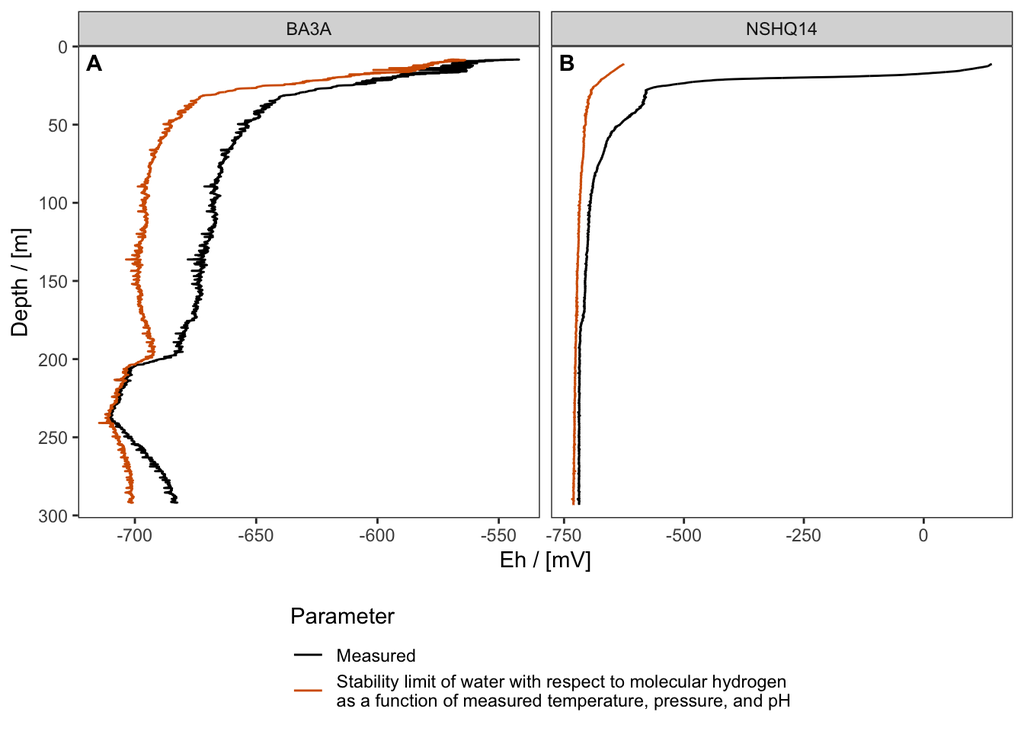

```r
plot_BA3A_NSHQ14_Eh %>% tag_facet_keep_strip(
 x = -Inf, y = -Inf, open = "", close = "",
          tag_pool = LETTERS
)
```

# Prepare data for facet plot Get relevant carbonate mineral isotope data

```r
data_NSHQ14_BA3A <- data_carb %>% select(sampling_site, Fm, depth_sampled_mbgl, carbonate_d13C_VPDB_permil)

# print
data_NSHQ14_BA3A
```

| sampling_site | Fm | depth_sampled_mbgl | carbonate_d13C_VPDB_permil |
| --- | --- | --- | --- |
| BA3A | 0.0110 | 4.340 | -14.99 |
| BA3A | 0.0568 | 5.160 | -7.67 |
| BA3A | 0.0782 | 7.425 | -8.56 |
| BA3A | 0.0414 | 5.700 | -9.74 |
| BA3A | 0.0157 | 5.700 | -9.62 |
| BA3A | 0.0037 | 8.215 | -12.92 |
| NSHQ14 | NA | 16.000 | -7.05 |
| NSHQ14 | NA | 139.000 | -4.75 |
| NSHQ14 | NA | 261.000 | -4.69 |

convert conductivity units

```r
NSHQ14_profile <- NSHQ14_profile %>% mutate(cond_mS_cm = cond_uS_per_cm/1000) %>% select(-cond_uS_per_cm) %>% mutate(sampling_site = "NSHQ14")
BA3A_profile <- BA3A_profile %>% mutate(cond_mS_cm = cond_uS_per_cm/1000) %>% select(-cond_uS_per_cm) %>% mutate(sampling_site = "BA3A")
```

Join well logs, and carbonate vein and isotope data

```r
# join by type column
NSHQ14_BA3A_profiles_and_isotopes <- full_join(NSHQ14_profile, data_NSHQ14_BA3A) %>% full_join(BA3A_profile) %>% full_join(BA3A_vein_types_carb) %>% arrange(depth_sampled_mbgl)
```

[output not shown]

```r
# print first few lines
head(NSHQ14_BA3A_profiles_and_isotopes)
```

| depth_sampled_mbgl | P_dbar | T_C | pH | ORP_mV_Ag_AgCl | Eh_mV | water_column_above_m | P_hydrostatic_calc_Pa | P_hydrostatic_calc_bar | P_bar | T_K | H2O_H2_limit_Eh_f_T_P_mV | cond_mS_cm | sampling_site | Fm | carbonate_d13C_VPDB_permil | vein_type_carbonate |
| --- | --- | --- | --- | --- | --- | --- | --- | --- | --- | --- | --- | --- | --- | --- | --- | --- |
| 1.16 | NA | NA | NA | NA | NA | NA | NA | NA | NA | NA | NA | NA | BA3A | NA | NA | 1 |
| 2.78 | NA | NA | NA | NA | NA | NA | NA | NA | NA | NA | NA | NA | BA3A | NA | NA | 1 |
| 2.89 | NA | NA | NA | NA | NA | NA | NA | NA | NA | NA | NA | NA | BA3A | NA | NA | 1 |
| 3.20 | NA | NA | NA | NA | NA | NA | NA | NA | NA | NA | NA | NA | BA3A | NA | NA | 1 |
| 3.30 | NA | NA | NA | NA | NA | NA | NA | NA | NA | NA | NA | NA | BA3A | NA | NA | 1 |
| 3.58 | NA | NA | NA | NA | NA | NA | NA | NA | NA | NA | NA | NA | BA3A | NA | NA | 1 |

## 5.1 Pivot longer for plotting on same scale

```r
NSHQ14_BA3A_profiles_and_isotopes_longer <- NSHQ14_BA3A_profiles_and_isotopes %>% select(-P_dbar, -ORP_mV_Ag_AgCl, -water_column_above_m, -P_hydrostatic_calc_Pa, -P_hydrostatic_calc_bar, -P_bar, -T_K, -H2O_H2_limit_Eh_f_T_P_mV) %>% pivot_longer(cols = c(-sampling_site, -depth_sampled_mbgl), names_to = "parameter", values_to = "value", values_drop_na = TRUE)

NSHQ14_BA3A_profiles_and_isotopes_longer
```

| depth_sampled_mbgl | sampling_site | parameter | value |
| --- | --- | --- | --- |
| 1.160000 | BA3A | vein_type_carbonate | 1.00000000 |
| 2.780000 | BA3A | vein_type_carbonate | 1.00000000 |
| 2.890000 | BA3A | vein_type_carbonate | 1.00000000 |
| 3.200000 | BA3A | vein_type_carbonate | 1.00000000 |
| 3.300000 | BA3A | vein_type_carbonate | 1.00000000 |
| 3.580000 | BA3A | vein_type_carbonate | 1.00000000 |
| 3.590000 | BA3A | vein_type_carbonate | 1.00000000 |
| 3.830000 | BA3A | vein_type_carbonate | 1.00000000 |
| 3.865000 | BA3A | vein_type_carbonate | 1.00000000 |
| 3.960000 | BA3A | vein_type_carbonate | 1.00000000 |

[output cut: 9990 more lines]

Prepping data to plot and label correctly

```r
# set factors to set order of parameters on plot
NSHQ14_BA3A_profiles_and_isotopes_longer$parameter <- factor(NSHQ14_BA3A_profiles_and_isotopes_longer$parameter, levels = c("T_C", "pH", "Eh_mV", "cond_mS_cm", "vein_type_carbonate", "carbonate_d13C_VPDB_permil", "Fm"))

# rename how parameters should be displayed on plot using LaTeX
NSHQ14_BA3A_profiles_and_isotopes_longer <- NSHQ14_BA3A_profiles_and_isotopes_longer %>%
  mutate(
    tex_params_overset = as_factor(parameter)%>%
      fct_recode(
        "T / $\\lbrack$$\\degree$C$\\rbrack$" = "T_C",
        "pH" = "pH",
        "Eh / $\\lbrack$mV$\\rbrack$" = "Eh_mV",
        "$\\overset{Conductivity}{/\\,$\\lbrack$mS$\\cdot$cm^{-1}$\\rbrack$}$" = "cond_mS_cm",
        "$\\overset{Veins\\,with}{carbonate,\\,BA3A}$" = "vein_type_carbonate",
        "$\\overset{Carbonate}{\\delta^{13}C\\,/\\,\\lbrack$‰$\\,VPDB\\rbrack}$" = "carbonate_d13C_VPDB_permil",
        "$\\overset{Carbonate}{fraction\\,modern}$" = "Fm"
  )
  )
```

## 5.2 Plot

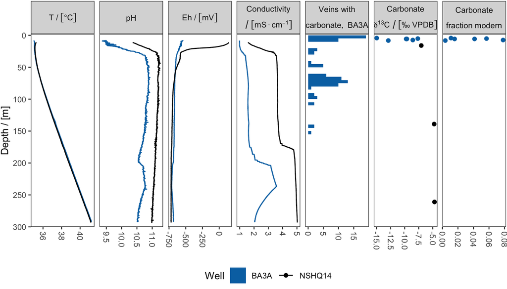

```r
NSHQ14_BA3A_profiles_and_isotopes_plot <- NSHQ14_BA3A_profiles_and_isotopes_longer %>% ggplot(aes(
  x = depth_sampled_mbgl,
  fill = sampling_site,
  color = sampling_site
  )) +

  # add line graph for applicable parameters
  geom_line(data = (NSHQ14_BA3A_profiles_and_isotopes_longer %>% filter(parameter == "T_C" | parameter == "pH" | parameter == "Eh_mV" | parameter == "cond_mS_cm")), aes(y = value)) +

  # add scatterplot for applicable parameters
  geom_point(data = (NSHQ14_BA3A_profiles_and_isotopes_longer %>% filter(parameter == "Fm" | parameter == "carbonate_d13C_VPDB_permil")), aes(y = value)) +

  # add histogram for applicable parameter
  geom_histogram(data = (NSHQ14_BA3A_profiles_and_isotopes_longer %>% filter(parameter == "vein_type_carbonate")), binwidth = 5, boundary = 0, color = NA) +

  # flip coordinates (this makes it possible to do vertical line graph)
    coord_flip() +

  # plot styling
  scale_fill_manual(name = "Well", values = c("NSHQ14" = "black", "BA3A" = "#0072B2"))+
  scale_color_manual(name = "Well", values = c("NSHQ14" = "black", "BA3A" = "#0072B2"))+
  scale_x_reverse(name = "Depth / [m]", limits = c(300, -2), expand = c(0, 0), breaks = c(0, 50, 100, 150, 200, 250, 300)) +
  scale_y_continuous(name = NULL) +

  # generate plot facets
  # facet_grid(cols = vars(params_recode), scales = "free", switch = "y")+
  # for alternative names
    facet_grid(cols = vars(tex_params_overset), scales = "free", labeller = latex_labeller, switch = "y")+

  # plot design
  theme_bw(base_size = 10) +
  theme(
    axis.text.x = element_text(angle = -90, vjust = 0.5, hjust = 0),
    legend.position = "bottom",
    legend.direction = "horizontal",
    panel.grid = element_blank(),
    plot.margin = margin(1,1,0,1)
  )

NSHQ14_BA3A_profiles_and_isotopes_plot
```

```r
equal_breaks <- function(n = 3, s = 0.05, ...){
  function(x){
    # rescaling
    d <- s * diff(range(x)) / (1+2*s)
    seq(min(x)+d, max(x)-d, length=n)
  }
}
```

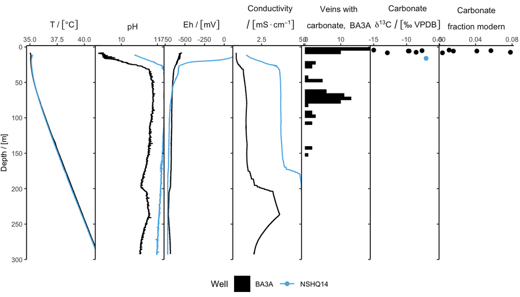

```r
NSHQ14_BA3A_profiles_and_isotopes_plot_clean <- NSHQ14_BA3A_profiles_and_isotopes_longer %>% ggplot(aes(
  x = depth_sampled_mbgl,
  fill = sampling_site,
  color = sampling_site
  )) +

  # add line graph for applicable parameters
  geom_line(data = (NSHQ14_BA3A_profiles_and_isotopes_longer %>% filter(parameter == "T_C" | parameter == "pH" | parameter == "Eh_mV" | parameter == "cond_mS_cm")), aes(y = value)) +

  # add scatterplot for applicable parameters
  geom_point(data = (NSHQ14_BA3A_profiles_and_isotopes_longer %>% filter(parameter == "Fm" | parameter == "carbonate_d13C_VPDB_permil")), aes(y = value)) +

  # add histogram for applicable parameter
  geom_histogram(data = (NSHQ14_BA3A_profiles_and_isotopes_longer %>% filter(parameter == "vein_type_carbonate")), binwidth = 5, boundary = 0, color = NA) +

  # flip coordinates (this makes it possible to do vertical line graph)
    coord_flip() +

  # plot styling
  scale_fill_manual(name = "Well", values = c("NSHQ14" = "#56B4E9", "BA3A" = "black"))+
  scale_color_manual(name = "Well", values = c("NSHQ14" = "#56B4E9", "BA3A" = "black"))+
  scale_x_reverse(name = "Depth / [m]", limits = c(300, -2), expand = c(0, 0), breaks = c(0, 50, 100, 150, 200, 250, 300)) +
  scale_y_continuous(name = NULL, sec.axis = dup_axis(), breaks = breaks_extended(n=3.5)) +

  # generate plot facets
  # facet_grid(cols = vars(params_recode), scales = "free", switch = "y")+
  # for alternative names
    # facet_grid(cols = vars(tex_params_overset), scales = "free", labeller = latex_labeller, switch = "y")+
  facet_rep_grid(cols = vars(tex_params_overset), scales = "free", labeller = latex_labeller, switch = "y")+

  # plot design
  theme_classic(base_size = 8.5) +
  theme(
    axis.text.x.top = element_text(size = 6.5),
    axis.text.y = element_text(size = 6.5),
    legend.position = "bottom",
    legend.direction = "horizontal",
    panel.grid = element_blank(),
    plot.margin = margin(0,6,0,1),
    strip.placement = "outside",
    strip.background = element_blank(),
    strip.text = element_text(vjust = 0, size = 8),
    axis.text.x.bottom = element_blank(),
    axis.ticks.x.bottom = element_blank(),
    axis.line.x.bottom = element_blank(),
    axis.line.y.left = element_line(),
    panel.spacing = unit(-8, "pt"),
    axis.title.y = element_text(size = 7.5)
  )

NSHQ14_BA3A_profiles_and_isotopes_plot_clean
```

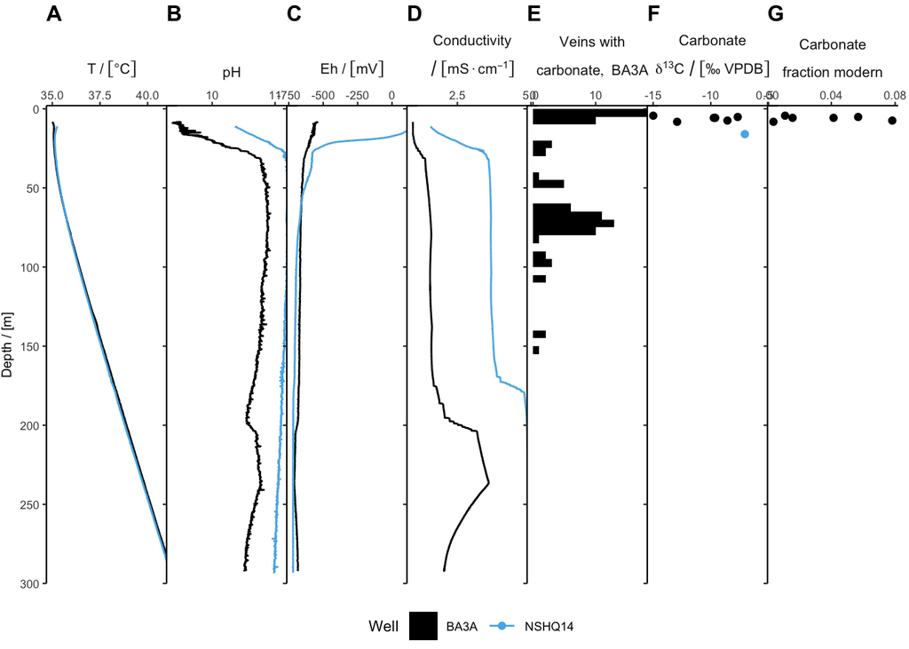

```r
NSHQ14_BA3A_profiles_and_isotopes_plot_clean %>% tag_facet_outside_keep_strip_no_side_tags(
  open = "",
  close = "",
  tag_fun_top = function(i) LETTERS[i]
)
```

# 6 Geotherm

## 6.1 NSHQ14

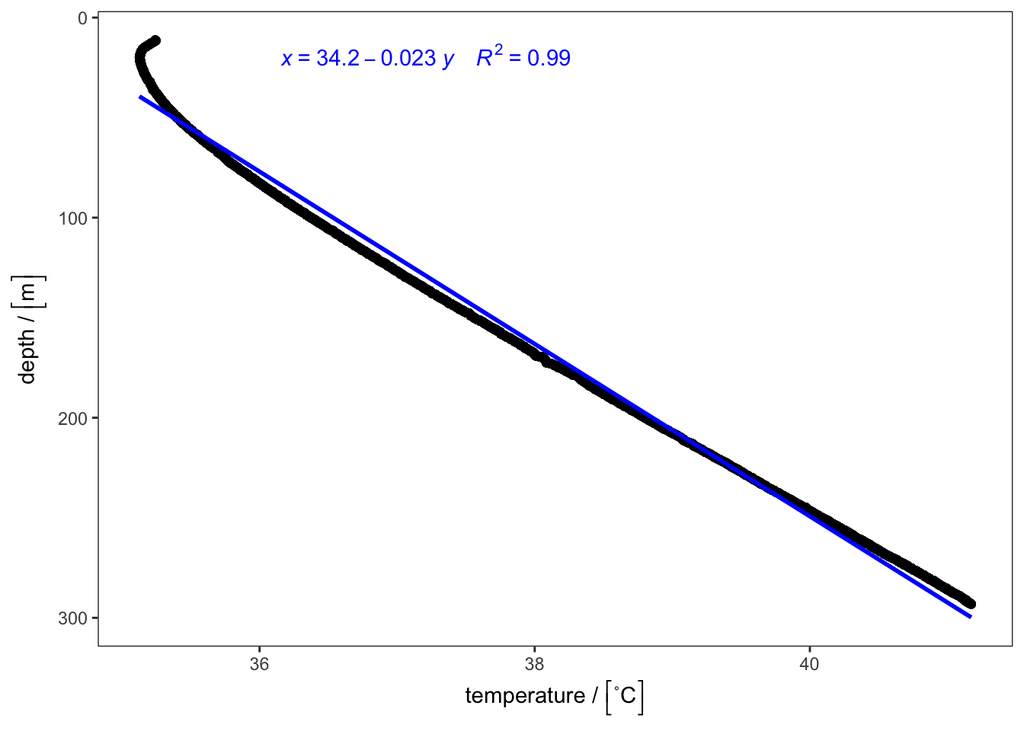

```r
plot_T_NSHQ14 <- NSHQ14_profile %>% ggplot( mapping = aes(
    x = T_C,
    y = depth_sampled_mbgl)) +
  geom_point() +
    geom_smooth(method="lm", color = "blue") +
  stat_poly_eq(aes(label =  paste(stat(eq.label), stat(rr.label), sep = "~~~~")),
               formula = x ~ y, parse = TRUE, rr.digits = 2, color = "blue", label.x = 0.2)+
  scale_y_reverse(name = latex2exp::TeX("depth$\\,$/$\\,$$\\left[$m$\\right]$"))+
    scale_x_continuous(name = latex2exp::TeX("temperature$\\,$/$\\,$$\\left[$˚C$\\right]$"))+
  theme_bw()+
  theme(
    panel.grid = element_blank()
  )

plot_T_NSHQ14
```

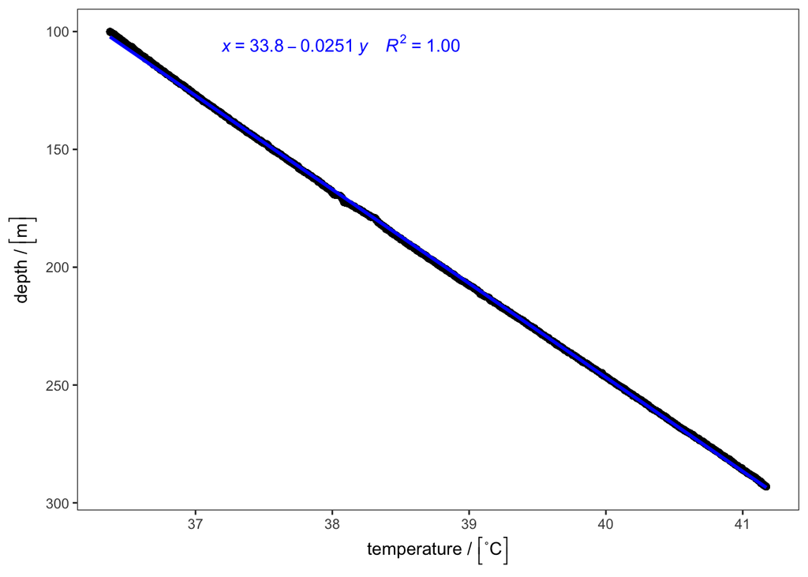

```r
NSHQ14_profile_below_100m <- NSHQ14_profile %>% filter(depth_sampled_mbgl > 100)

plot_T_NSHQ14_below_100m <- NSHQ14_profile_below_100m %>% ggplot( mapping = aes(
    x = T_C,
    y = depth_sampled_mbgl)) +
  geom_point() +
    geom_smooth(method="lm", color = "blue") +
  stat_poly_eq(aes(label =  paste(stat(eq.label), stat(rr.label), sep = "~~~~")),
               formula = x ~ y, parse = TRUE, rr.digits = 2, color = "blue", label.x = 0.2)+
  scale_y_reverse(name = latex2exp::TeX("depth$\\,$/$\\,$$\\left[$m$\\right]$"))+
    scale_x_continuous(name = latex2exp::TeX("temperature$\\,$/$\\,$$\\left[$˚C$\\right]$"))+
    theme_bw()+
  theme(
    panel.grid = element_blank()
  )

plot_T_NSHQ14_below_100m
```

```r
# generate linear model
model_T_d_NSHQ14_below_100m = lm(T_C ~ depth_sampled_mbgl,
           data = NSHQ14_profile_below_100m)

# print model summary
summary(model_T_d_NSHQ14_below_100m)
```

```
##
## Call:
## lm(formula = T_C ~ depth_sampled_mbgl, data = NSHQ14_profile_below_100m)
##
## Residuals:
##       Min        1Q    Median        3Q       Max
## -0.053155 -0.014659 -0.002923  0.013311  0.060838
##
## Coefficients:
##                     Estimate Std. Error t value Pr(>|t|)
## (Intercept)        3.381e+01  5.165e-04   65463   <2e-16 ***
## depth_sampled_mbgl 2.508e-02  2.528e-06    9923   <2e-16 ***
## ---
## Signif. codes:  0 '***' 0.001 '**' 0.01 '*' 0.05 '.' 0.1 ' ' 1
##
## Residual standard error: 0.01959 on 19316 degrees of freedom
## Multiple R-squared:  0.9998, Adjusted R-squared:  0.9998
## F-statistic: 9.846e+07 on 1 and 19316 DF,  p-value: < 2.2e-16
```

## 6.2 BA3A

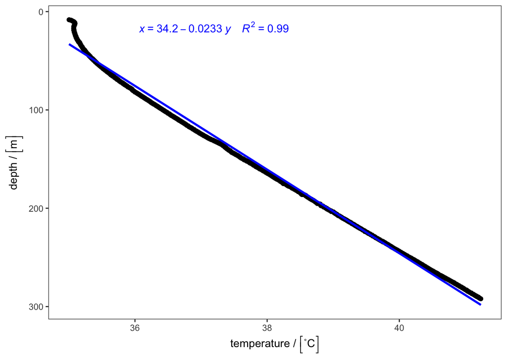

```r
plot_T_BA3A <- BA3A_profile %>% ggplot( mapping = aes(
    x = T_C,
    y = depth_sampled_mbgl)) +
  geom_point() +
    geom_smooth(method="lm", color = "blue") +
  stat_poly_eq(aes(label =  paste(stat(eq.label), stat(rr.label), sep = "~~~~")),
               formula = x ~ y, parse = TRUE, rr.digits = 2, color = "blue", label.x = 0.2)+
  scale_y_reverse(name = latex2exp::TeX("depth$\\,$/$\\,$$\\left[$m$\\right]$"))+
    scale_x_continuous(name = latex2exp::TeX("temperature$\\,$/$\\,$$\\left[$˚C$\\right]$"))+
  theme_bw()+
  theme(
    panel.grid = element_blank()
  )

plot_T_BA3A
```

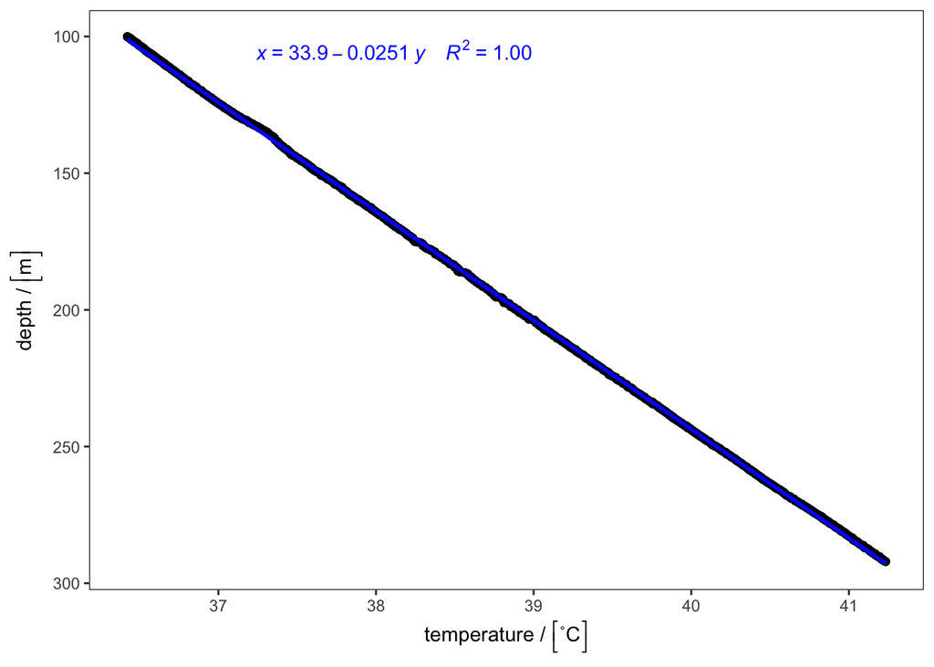

```r
BA3A_profile_below_100m <- BA3A_profile %>% filter(depth_sampled_mbgl > 100)

plot_T_BA3A_below_100m <- BA3A_profile_below_100m %>% ggplot( mapping = aes(
    x = T_C,
    y = depth_sampled_mbgl)) +
  geom_point() +
    geom_smooth(method="lm", color = "blue") +
  stat_poly_eq(aes(label =  paste(stat(eq.label), stat(rr.label), sep = "~~~~")),
               formula = x ~ y, parse = TRUE, rr.digits = 2, color = "blue", label.x = 0.2)+
  scale_y_reverse(name = latex2exp::TeX("depth$\\,$/$\\,$$\\left[$m$\\right]$"))+
    scale_x_continuous(name = latex2exp::TeX("temperature$\\,$/$\\,$$\\left[$˚C$\\right]$"))+
    theme_bw()+
  theme(
    panel.grid = element_blank()
  )

plot_T_BA3A_below_100m
```

```r
# generate linear model
model_T_d_BA3A_below_100m = lm(T_C ~ depth_sampled_mbgl,
           data = BA3A_profile_below_100m)

# print model summary
summary(model_T_d_BA3A_below_100m)
```

```
##
## Call:
## lm(formula = T_C ~ depth_sampled_mbgl, data = BA3A_profile_below_100m)
##
## Residuals:
##       Min        1Q    Median        3Q       Max
## -0.031482 -0.007958 -0.003657  0.005497  0.039192
##
## Coefficients:
##                     Estimate Std. Error t value Pr(>|t|)
## (Intercept)        3.388e+01  3.134e-04  108111   <2e-16 ***
## depth_sampled_mbgl 2.510e-02  1.538e-06   16320   <2e-16 ***
## ---
## Signif. codes:  0 '***' 0.001 '**' 0.01 '*' 0.05 '.' 0.1 ' ' 1
##
## Residual standard error: 0.01182 on 19208 degrees of freedom
## Multiple R-squared:  0.9999, Adjusted R-squared:  0.9999
## F-statistic: 2.663e+08 on 1 and 19208 DF,  p-value: < 2.2e-16
```